# 100 top tracks of 2018 From Spotify

Tingting Zheng

February 23, 2020

# Project Description

Nowadays we use Spotify almost every day not only for entertainment, but also for study. We are going to to look for patterns in the audio features of the songs. We will try to predict one audio feature based on the others.

## Research Question

**Question: Will the loudness affect the energy of a song?**

## Variables

*The explanatory variable is the loudness. The response variable is the energy.*

# Exploratory Data Analysis (EDA)

# Data Description

*This is a data-set of 100 top tracks of 2018 From Spotify. Each row represents a track. The id column is the categorical variable which is the Spotify’s identification of the song. The name column is also the categorical variable and shows the name of each video. The artists column is the categorical variable which displays artist(s) of the song. The danceability column is a numerical variable and displays how suitable a track is for dancing based on a combination of musical elements including tempo, rhythm stability, beat strength, and overall regularity. The energy column is the numerical variable which is a measure from 0.0 to 1.0 and represents a perceptual measure of intensity and activity. The key column is the categorical variable. The key the track is in. Integers map to pitches using standard pitch Class notation. E.g. 0=C, 2=D, and so on. The loudness column is the numerical variable. The overall loudness of a track in decibels (dB). The mode column is the quantitative variable. Mode indicates the modality (major or minor) of a track, the type of scale from which its melodic content is derived. The speechiness column is the quantitative variable. Speechiness detects the presence of spoken words in a track. The more exclusively speech-like the recording (e.g. talk show, audio book, poetry), the closer to 1.0 the attribute value. The acousticness column is the quantitative variable. A confidence measure from 0.0 to 1.0 of whether the track is acoustic. The instrumentalness column is the quantitative variable. Predicts whether a track contains no vocals. The liveness column is the quantitative variable which detects the presence of an audience in the recording. The valence column is the quantitative variable. It’s a measure from 0.0 to 1.0 describing the musical positiveness conveyed by a track. The tempo column is the quantitative variable. The overall estimated tempo of a track in beats per minute (BPM). The duration_ms column is the quantitative variable. It is the duration of the track in milliseconds. The time_signature column is the quantitative variable which is an estimated overall time signature of a track. The time signature (meter) is a notational convention to specify how many beats are in each bar (or measure). The explanatory variable is the loudness. The response variable is the energy.*

# Statistical Analysis

*Read the data into R and conduct some initial summaries of your exploratory and response data.*

```r
top2018<-read.csv("top2018.csv")
attach(top2018) # The database "top2018 is attached to the R search path
summary(top2018) # To produce result summaries of the data from top2018.
```

```
##       id                name             artists           danceability
##  Length:100         Length:100         Length:100         Min.   :0.2580
##  Class :character   Class :character   Class :character   1st Qu.:0.6355
##  Mode  :character   Mode  :character   Mode  :character   Median :0.7330
##                                                           Mean   :0.7165
##                                                           3rd Qu.:0.7983
##                                                           Max.   :0.9640
##      energy            key           loudness            mode
##  Min.   :0.2960   Min.   : 0.00   Min.   :-10.109   Min.   :0.00
##  1st Qu.:0.5620   1st Qu.: 1.75   1st Qu.: -6.651   1st Qu.:0.00
##  Median :0.6780   Median : 5.00   Median : -5.566   Median :1.00
##  Mean   :0.6591   Mean   : 5.33   Mean   : -5.678   Mean   :0.59
##  3rd Qu.:0.7722   3rd Qu.: 8.25   3rd Qu.: -4.364   3rd Qu.:1.00
##  Max.   :0.9090   Max.   :11.00   Max.   : -2.384   Max.   :1.00
##   speechiness       acousticness      instrumentalness       liveness
##  Min.   :0.02320   Min.   :0.000282   Min.   :0.000e+00   Min.   :0.02150
##  1st Qu.:0.04535   1st Qu.:0.040225   1st Qu.:0.000e+00   1st Qu.:0.09467
##  Median :0.07495   Median :0.109000   Median :0.000e+00   Median :0.11850
##  Mean   :0.11557   Mean   :0.195701   Mean   :1.584e-03   Mean   :0.15830
##  3rd Qu.:0.13700   3rd Qu.:0.247750   3rd Qu.:3.087e-05   3rd Qu.:0.17075
##  Max.   :0.53000   Max.   :0.934000   Max.   :1.340e-01   Max.   :0.63600
##     valence           tempo         duration_ms     time_signature
##  Min.   :0.0796   Min.   : 64.93   Min.   : 95467   Min.   :3.00
##  1st Qu.:0.3410   1st Qu.: 95.73   1st Qu.:184680   1st Qu.:4.00
##  Median :0.4705   Median :120.12   Median :205048   Median :4.00
##  Mean   :0.4844   Mean   :119.90   Mean   :205207   Mean   :3.98
##  3rd Qu.:0.6415   3rd Qu.:140.02   3rd Qu.:221493   3rd Qu.:4.00
##  Max.   :0.9310   Max.   :198.07   Max.   :417920   Max.   :5.00
```

```r
dim(top2018) # to get dimensions Of data top2018
```

```
## [1] 100  16
```

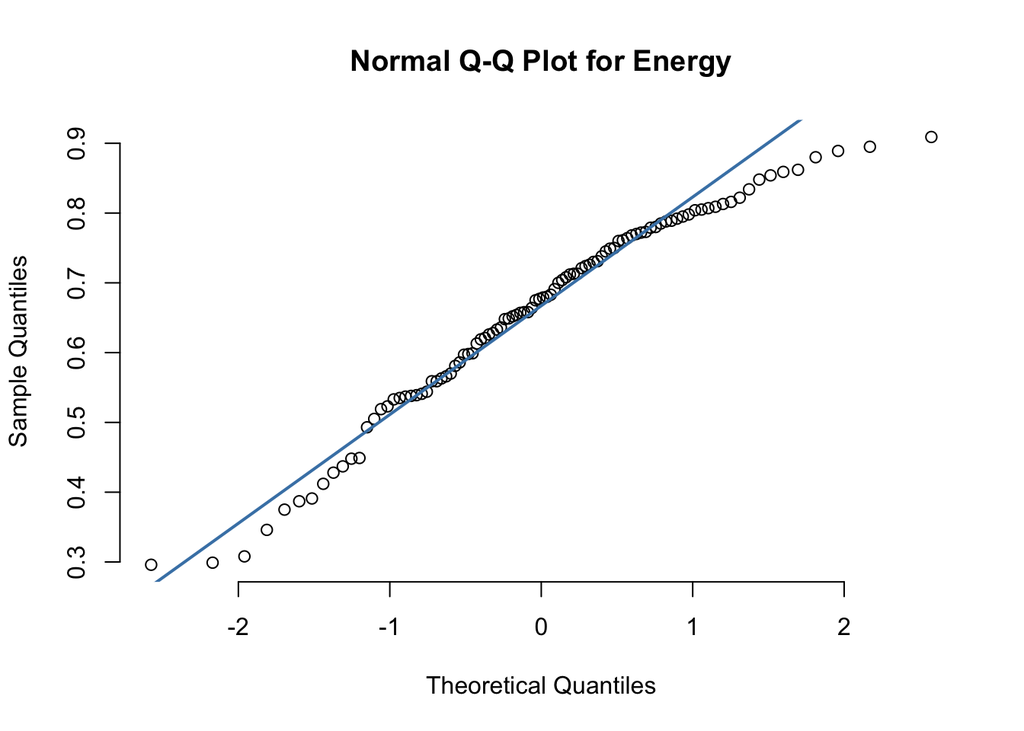

```r
qqnorm(top2018$energy, pch = 1, frame = FALSE, main = "Normal Q-Q Plot for Energy") # produces a normal QQ plot of the value energy
qqline(top2018$energy, col = "steelblue", lwd = 2) # adds a line to a “theoretical”, by default normal, quantile-quantile plot
```

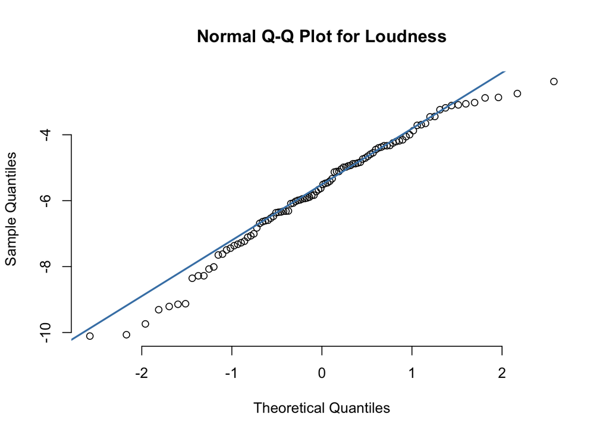

```r
qqnorm(top2018$loudness, pch = 1, frame = FALSE, main = "Normal Q-Q Plot for Loudness") # produces a normal QQ plot of the value loudness
qqline(top2018$loudness, col = "steelblue", lwd = 2) # adds a line to a “theoretical”, by default normal, quantile-quantile plot
```

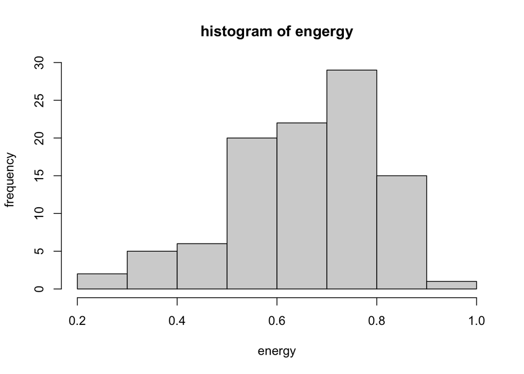

```r
hist(top2018$energy, main = "histogram of engergy", xlab = "energy", ylab = "frequency") # produce a histogram of energy
```

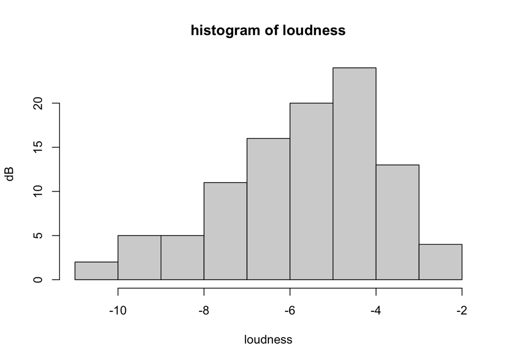

```r
hist(top2018$loudness, main = "histogram of loudness", xlab = "loudness", ylab = "dB") # produce a histogram of loudness
```

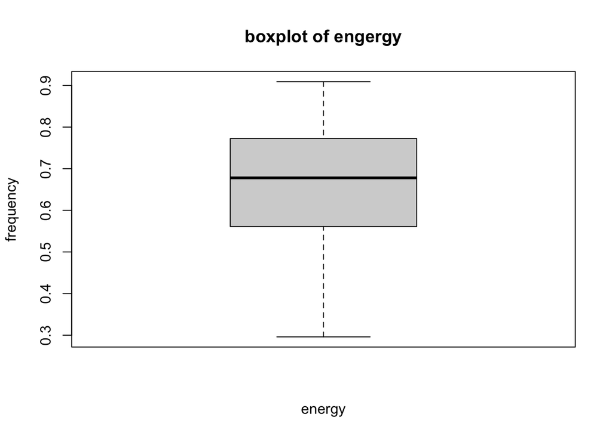

```r
boxplot(top2018$energy, main = "boxplot of engergy", xlab = "energy", ylab = "frequency") # produce a boxplot of engergy
```

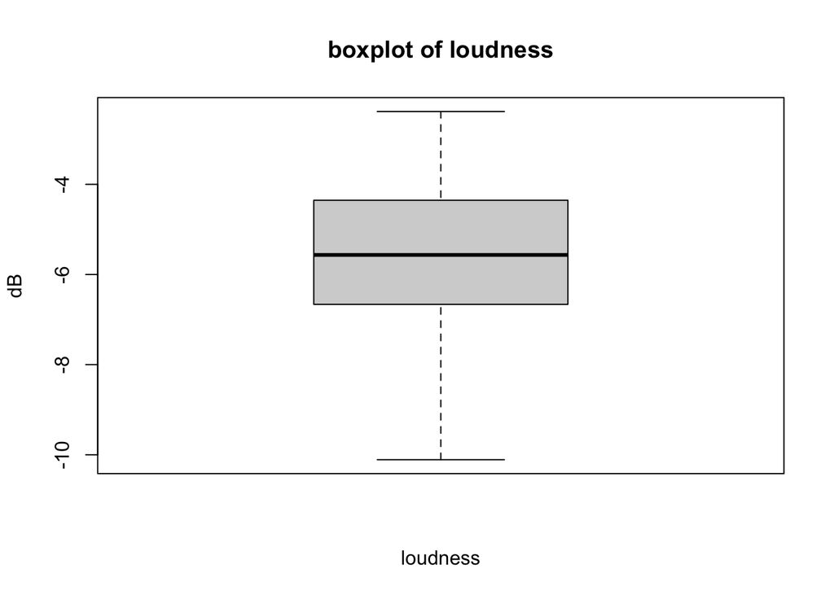

```r
boxplot(top2018$loudness, main = "boxplot of loudness", xlab = "loudness", ylab = "dB") # produce a boxplot of loudness
```

*Create a scatter plot of your explanatory and response variables. Describe the relationship’s form, direction and strength and any outliers or features.*

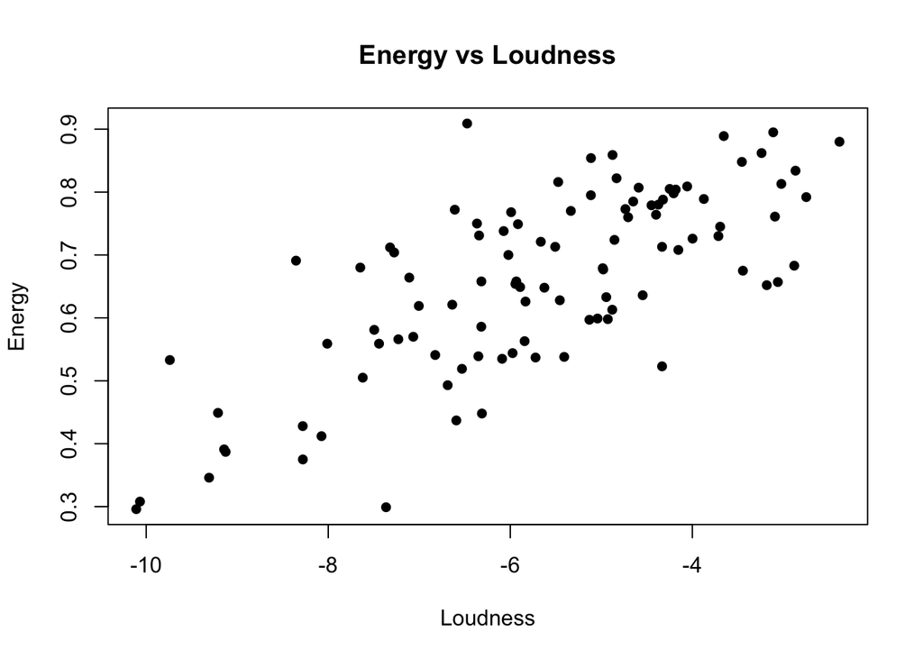

```r
plot(x = top2018$loudness,
     y = top2018$energy,
     main = "Energy vs Loudness",
     xlab = "Loudness",
     ylab = "Energy",
     pch = 16) # A scatterplot of energy and loudness. With loudness in the x-axis, energy in the y-axis.
```

*From the scatterplot, we can find that there is a positive, moderate, and linear relationship between Variable Loudness and Energy. And there is no obvious outlier shown in the scatter plot.* *Use R to calculate the correlation coefficient and its 99% confidence interval.*

```r
cor.test(loudness,energy,conf.level=0.99) # Test For Correlation Between loudness and energy and it's 99% confidence interval
```

```
##
##  Pearson's product-moment correlation
##
## data:  loudness and energy
## t = 10.659, df = 98, p-value < 2.2e-16
## alternative hypothesis: true correlation is not equal to 0
## 99 percent confidence interval:
##  0.5869744 0.8324640
## sample estimates:
##       cor
## 0.7327191
```

*The 99% confidence interval is from 0.5869744 to 0.8324640. The correlation coefficient is 0.7327191.*

*Use R to create a linear model between two variables and save it to a variable called fit1.*

```r
Fit1=lm(energy~loudness,data=top2018) #creat a linear model between energy and loudness
summary(Fit1) # To produce result summaries of the linear model Fit1
```

```
##
## Call:
## lm(formula = energy ~ loudness, data = top2018)
##
## Residuals:
##       Min        1Q    Median        3Q       Max
## -0.259161 -0.081389  0.004101  0.060680  0.297560
##
## Coefficients:
##             Estimate Std. Error t value Pr(>|t|)
## (Intercept)  0.99857    0.03336   29.93   <2e-16 ***
## loudness     0.05980    0.00561   10.66   <2e-16 ***
## ---
## Signif. codes:  0 '***' 0.001 '**' 0.01 '*' 0.05 '.' 0.1 ' ' 1
##
## Residual standard error: 0.09923 on 98 degrees of freedom
## Multiple R-squared:  0.5369, Adjusted R-squared:  0.5322
## F-statistic: 113.6 on 1 and 98 DF,  p-value: < 2.2e-16
```

*y=0.05980x+0.99857, where y is the energy, x is the loudness, b1=0.05980, b0=0.99857.* *For the regression model, it indicates that when loudness equals to 0, the energy is 0.99857. And for each unit increased in loudness, the energy will increase 0.05980.*

*identify the R2 and adjusted R2 values*

```r
summary(Fit1) # To produce result summaries of the linear model Fit1
```

```
##
## Call:
## lm(formula = energy ~ loudness, data = top2018)
##
## Residuals:
##       Min        1Q    Median        3Q       Max
## -0.259161 -0.081389  0.004101  0.060680  0.297560
##
## Coefficients:
##             Estimate Std. Error t value Pr(>|t|)
## (Intercept)  0.99857    0.03336   29.93   <2e-16 ***
## loudness     0.05980    0.00561   10.66   <2e-16 ***
## ---
## Signif. codes:  0 '***' 0.001 '**' 0.01 '*' 0.05 '.' 0.1 ' ' 1
##
## Residual standard error: 0.09923 on 98 degrees of freedom
## Multiple R-squared:  0.5369, Adjusted R-squared:  0.5322
## F-statistic: 113.6 on 1 and 98 DF,  p-value: < 2.2e-16
```

*R2 equals to 0.5369(53.69%), and adjusted R2 equals to 0.5322(53.22%).* *Add the line of best fit to the scatter plot.*

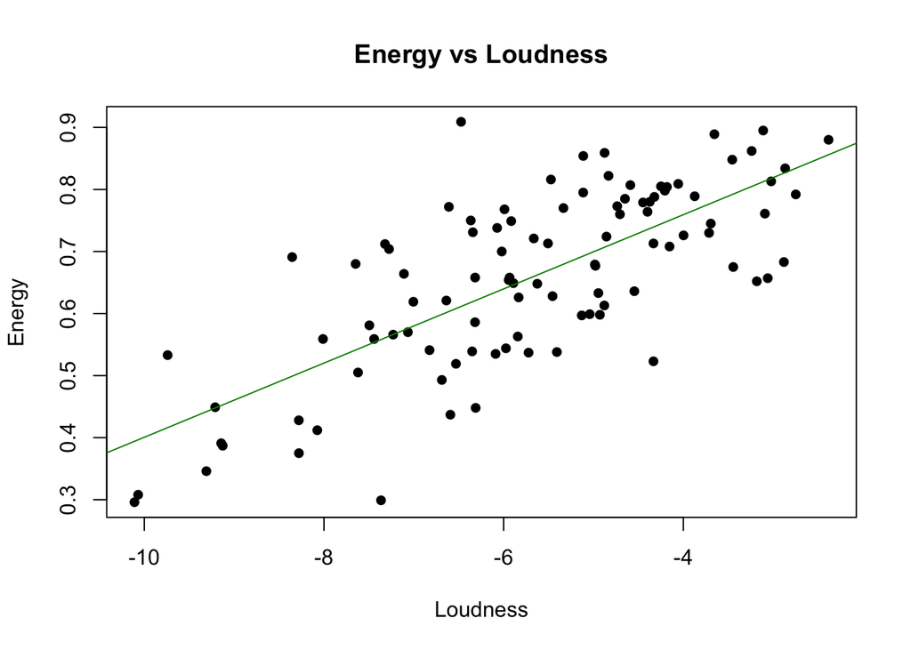

```r
plot(x = top2018$loudness,
     y = top2018$energy,
     main = "Energy vs Loudness",
     xlab = "Loudness",
     ylab = "Energy",
     pch = 16) # produce the scatter plot of energy and loudness, with loudness in the x-axis, energy in the y-axis
abline(lm(energy~loudness, data=top2018), col='green4') # add the line of the best fit into the scatter plot
```

# result

*Conduct a hypothesis test to assess whether there a (linear) relationship between the explanatory and response variable.* *H0:The loudness is not a significant explanotary variable for predicting energy (β1=0)* *H1:The loudness is a significant explanotary variable for predicting energy (β1 not equal to 0)*

```r
T=(0.05980-0)/0.00561 # use a t-test to determine if loudness is a significant explanotary variable for energy
2*pt(T,df=98,lower.tail = FALSE) # because it's two tails, so we should times two to get the p-value
```

```
## [1] 4.506288e-18
```

*So p-value=4.506288e-18 which is smaller than 0.05, so we can reject hypothesis and conclude that we have sufficient evidence that the loudness is significant explanatory variable for predicting energy (β1 not equal to 0)*

# Resources

**Nadin Tamer (2019). Top Spotify Tracks of 2018 [Data file]. Retrieved from https://www.kaggle.com/nadintamer/top-spotify-tracks-of-2018**

**What the dataset is and where it is from.**

**4 Ways that Music and Mathematics are Related. (2019, October 13). Retrieved September 22, 2020, from https://www.omahaschoolofmusicanddance.com/our-blog/4-ways-that-music-and-mathematics-are-related/**

**How music and math related to each other**

**Gaab, N. (2017, May 01). Is There a Link between Music and Math? Retrieved September 22, 2020, from https://www.scientificamerican.com/article/is-there-a-link-between-music-and-math/**

**What is the relationship between math and music.**

**Foundation, C. (n.d.). 12 Foundation. Retrieved September 22, 2020, from https://flexbooks.ck12.org/cbook/ck-12-physics-flexbook-2.0/section/12.3/primary/lesson/intensity-and-loudness-of-sound-ms-ps**

**Use the knowledge of physics to understand the energy and loudness of sound.**

**Malkin, J., Li, X., & Bilmes, J. (2005). Energy and loudness for speed control in the vocal joystick. Retrieved September 22, 2020, from https://ieeexplore.ieee.org/document/1566489/citations?tabFilter=papers**

**It proposes and describes several methods for using speech power as an estimate of intentional loudness, and a mapping from this loudness estimate to a continuous control.**

**Ford, C. (2015, August 26). University of Virginia Library Research Data Services + Sciences. Retrieved September 22, 2020, from https://data.library.virginia.edu/understanding-q-q-plots/**

**It first gives a clear definition of normal QQ plot to help readers quickly understand what normal QQ plot is. More importantly, it combines images to teach readers how to get information from the images of normal QQ plot.**